# Bent Fall 2006

R. G. Cronce

12/19/2019

# Bent Brain Ticklers, Fall 2006

## Problem 1

```
The wife of a man who grew barley
Was also the sister of Charlie.
Her neighbor grew hay
And was married to Ray,
And one of these girls was named Carly.
The girl who was married to Wayne
Lived next to the farm that grew grain.
She liked to eat celery
That was grown by Valerie,
And she weighed 80 more pounds than Jane.
The woman whose husband grew dill
Was never married to Bill.
Before Jane married Benny
And Ray married Jenny,
She went out drinking with Jill.

Who is married to whom, and what does each couple grow?
Only one couple has rhyming names.

-- Technology Review
```

TODO

```
meh
```

## Problem 2

```
Uncle Wilbur was rich enough in life to command
the boundless devotion of his family. However,
some of them he despised, and some he merely
disliked.  Therefore, he repaid them by leaving
his entire estate to be divided equally among the
581 inmates of a home for retired greyhound racing
dogs. The sum involved ran to five figures and,
when divided, gave each dog a whole number of
dollars. By coincidence, the exact number of
relatives he despised happens to equal the first
two digits of the value of his estate, and the
third digit is the number he merely disliked. The
last two digits equal the number of his kinsfolk,
that is the sum of those he despised and those he
merely disliked.  How much money did each dog get?

-- Adapted from Martin Hollis
```

TODO

Probably would do exhaustive search.

```r
# Get the multiples of 581
x=(10000:99999)[(10000:99999) %% 581 == 0]

despised=trunc(x/1000)
disliked=(trunc(x/100)%%10)
kinsfolk=x%%100

k = ((despised+disliked) == kinsfolk) & (despised>0) & (disliked>0)

x[k]
```

```
## [1] 91798
```

```r
x[k]/581
```

```
## [1] 158
```

```
The original sum was 91798
Each dog received 158
```

## Problem 3

```
A 3 m by 3 m rug that is 1 cm thick is rolled up
on a wooden cylinder 10 cm in diameter. Assume
that the first wrap leaves a small gap between the
rug and the cylinder (assume that the bottom
surface of the rug forms a straight line between
the wooden cylinder and the edge of the rug), but
that there are no other gaps in the roll. What is
the distance from the outer edge of the rolled rug
to the center of the wooden cylinder?

-- Oscar C. Bascara, NY D '90
```

Solution:

```
Each time you wrap the rug around the cyclinder the radius
increases by 1 cm --> diameter increases by 2 cm.

First wrap: D=10cm  --> circumference = pi*10
    remaining rug length ~ 300-10*pi = 268.58

Second wrap: D=12cm --> circumference = pi*12
    remainder = 230.855
...

Sixth wrap: D=20cm --> remainder = 17.257 cm

Not enough for a complete seventh wrap.

Final diamter = 22 (inner diameter for wrapping the rug)

The outer diameter = 22+2 = 24 cm --> outer radius = 12 cm.
```

## Problem 4

```
A spherical plum pudding of radius R contains N
infinitely small plums, randomly distributed. What
is the expected distance of the nearest one from
the surface?

-- W.A. Whitworth, 1901
```

Solution:

```
This is the spherical equivalent to the cone problem
from 2006 Spring.  In this solution they give a much
clearer explanation of the calculations.

The multiplication by N for the N plums is specifically
noted.

Here he uses a differential shell as the probability region.
The ratio of the internal shere to the full sphere is the
probability that this plum is nearest the surface.  The
exponent here is (N-1) for the N-1 other plums.

So we have:

Pr (inside the diff slice) = 4*pi*r**2*dr/(4/3*pi*R**3)

Pr (other plums inside) = ((4/3*pi*r**3)/(4/3*pi*R**3))**(N-1)

Expected value:

E = N * integrate(r*3*r**2/R**3*(r**3/R**3)**(N-1),(r,0,R))

  = 3*N*R/(3*N+1)

This is the expected value of the distance from the center
of the sphere.  The distance to the outside:

D = R - E = R/(3*n+1)

Note: need to help Sympy with the integral by declaring
n as positive integer and declare R as positive.  Note
that the equation above uses N but it is probably better
to use a symbol of lower case n in sympy to avoid collision
with the N() function.
```

## Problem 5

```
A flexible string of length L hangs from the
bottom of a spherical fixture of radius R. The
string swings back and forth in a plane. What is
the maximum area that the string can sweep out?
(Assume L < pi*R.)

-- adapted from Howard P. Dinesman
```

WARNING: the solution given in the Bent has something wrong. The given integral does not equal the final value. I think the limits on the integral should be 0 to +L instead of -L to +L.

Solution: I don’t really understand this problem. Is this a 2D or a 3D problem? Can the plane be horizontal? If it must be vertical then I can see the problem. As the string wraps around the spherical support is deviates from the perfect circle. Below the level of the sphere the string will sweep out a perfect circle:

```
A1 = 1/2 * pi * L**2
```

For angles of the string where it partially wraps around the sphere the string is tangent to the sphere with a length less than L. As it wraps more and more the length gets shorter. If we call the angle for the portion of the sphere that is wrapped with the string as theta then:

```
arc length = L*theta

length of string = L - R*theta

Can I just integrate this as 1/2*(L-R*theta)*dtheta*(L-R*theta)?
Apparenty not.  This doesn't work.

point of tangency: x0,y0
    x0 = R*sin(theta)
    y0 = R-R*cos(theta)

Slope of tangent line = tan(theta)

End of string: x = x0 + (L-R*theta)*cos(theta)
               y = y0 + (L-R*theta)*sin(theta)

Substituting:

    x=R*sin(theta)+(L-R*theta)*cos(theta)
    y=R-R*cos(theta)+(L-R*theta)*sin(theta)

What does this look like in a plot?
```

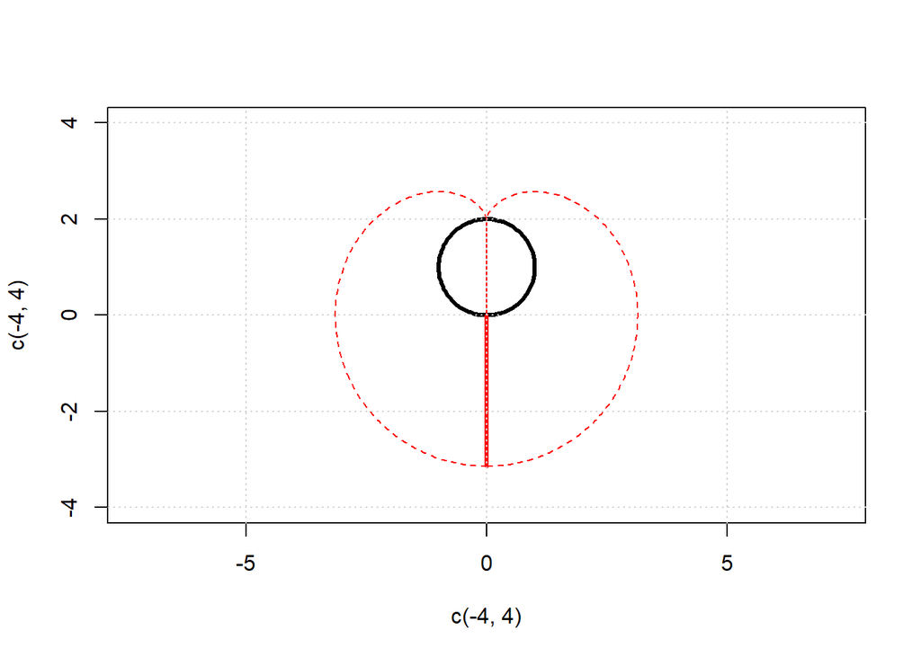

```r
R=1
L=pi*R

plot(c(-4,4),c(-4,4),type='n',asp=1)
theta=seq(0,2*pi,length=100)
x_sphere=R*cos(theta)
y_sphere=R+R*sin(theta)
polygon(x_sphere,y_sphere,lwd=3)

lines(c(0,0),c(0,-L),col='red',lwd=3)

# Semicircle for the lower half
theta=seq(-pi/2,0,length=100); x_1=L*cos(theta); y_1=L*sin(theta)

# Strange reducing circle for upper half
theta=seq(0,pi,length=100)
x_2=R*sin(theta)+(L-R*theta)*cos(theta)
y_2=R-R*cos(theta)+(L-R*theta)*sin(theta)

polygon(c(x_1,x_2),c(y_1,y_2),border='red',lty='dashed')
polygon(-1*c(x_1,x_2),c(y_1,y_2),border='red',lty='dashed')
grid()
```

Now I understand the difficulty.

Need to work on this some more.

## Bonus

```
A needle of length l is thrown randomly onto a
ruled grid. The horizontal spacing of the grid is
d1 and the vertical spacing of the grid is d2.
What is the probability that the needle will cross
either a horizontal or a vertical line (or both)?
Consider only the case where l<d1<d2.

-- adapted from P.S. Laplace, 1821
```

TODO

```
Buffon needle problem
```

## Double Bonus

```
It has been said that if enough monkeys were given
enough time with enough typewriters, they would
eventually reproduce all of the works of
Shakespeare. Suppose that there are 10,000,000
monkeys, each typing the 26 lower case letters
plus the space bar at random, at 10 characters per
second. What is the expected time interval between
occurrences of the sequence "wherefore art thou
romeo"?

-- Byron R. Adams, TX Alpha '58
```

Solution:

```
Nothing really tricky here -- just big numbers.

The phrase has 24 characters so we are looking for a particular
sequence in base 27.

    27^24 = 2.252e34

    Character rate = 1e8 characters per second

    Time = 2.253e26 seconds
         = 2.607e21 days
         = 7.144e18 years (assuming 365 days/year)

    Which is, of course, much longer than the age of the universe.

On the other hand, it might happen twice in 48e-8 seconds!
```